# S3_Informe

# Análisis de la morfología corporal de los estudiantes becados en UTEC.

*INTRODUCCIÓN*

### Relevancia

- La relevancia del estudio es alta debido a la coyuntura actual de el estudio virtual. El estudio virtual esta generando, entre los estudiantes, hábitos dañinos para la salud. Entre estos hábitos podemos encontrar el sedentarismo y la falta de actividad física. En este estudio nos enfocaremos en los estudiantes becados. Los estudiantes becados será el grupo que particularmente encontrará este estudio relevante debido a que este grupo cuenta con una presión extra de tener buenas notas y mantener los apoyos que se les ofrecen. Esta presión puede generar que los estudiantes estén mas horas frente al computador y dejen de lado la actividad física. Esto a su vez puede generar que exista problemas de obesidad y consecuentemente problemas de salud.

### Alcance del proyecto

- El proyecto hará un análisis descriptivo, tanto numérica como gráficamente, de las relaciones entre el ejercicio, IMC y obesidad en estudiantes becados.

### Parámetros del estudio.

- El estudio se basará en la clasificación de obesidad según el IMC. Esta información es recopilada del la OMS ( Organización mundial de la salud) y usaremos el IMC como principal índice.
- **Población**: Estudiantes de UTEC.
- **Unidad muestral**: Estudiante encuestado.
- **Muestreo**: Muestreo por conveniencia.
- **Tamaño de la muestra**: El tamaño de la muestra es 203 observaciones.

## Manejo de datos

### Recolección de datos

- La Recolección de datos se desarrolló por medio de una encuesta vía google forms. El equipo considero que era el mejor medio para llevar a cabo una encuesta de satisfacción, debido a que nos permite asignar preguntas de opción múltiple, además de permitirnos tener toda la información organizada en hojas de cálculo de excel. Para poder llegar a nuestra población objetivo, procuramos enviar el link de la encuesta a grupos conformados por estudiantes de UTEC mediante las redes sociales.

### Variables

##### Categórica nominal:

- *Género*
- *Carrera*
- *Departamento de origen*
- *Es Becado*
- *Entidad que financia la beca*
- *Tipo de beca*
- *Carrera*
- *Impacto económico de la beca en la situación financiera del estudiante*

##### Categórica ordinal

- *Año de ingreso*: Restricción: Colocar el año de su ingreso a la universidad, sin guiones(ejm.2020).
- *Ciclo*: Restricción: marcar una de las opciones.

##### Numérica discreta

- **Edad**: Restricción: marcar cualquiera de las opciones.
- **Horas** semanales que realiza alguna actividad física.
- **Años de becario**

##### Numérica continua

- **Estatura**: Restricción: ingresar como separador decimal el punto y aproximar a dos decimales.
- **Peso**: Restricción: ingresar como separador decimal el punto y aproximar a dos decimales.

### LIMPIEZA DE DATOS

La encuesta que se realizó fue directa y se limitó la entrada de los encuestados. Todos los campos tenían opciones múltiples y en los valores numéricos no se registró valores mal ingresados. Se realizó cambio en el nombre de las variables para mejor manejo.

| Genero | Edad | Estatura | Peso | AnoIngreso | Ciclo | Carrera | Region | EsBecado | Financiador | Beca | AnoBeneficio | EscalaImpactoEconomico | ExisteIntegracion | HorasEjercicio |
| --- | --- | --- | --- | --- | --- | --- | --- | --- | --- | --- | --- | --- | --- | --- |
| Masculino | 20 | 1.68 | 100 | 2020 | 2 | Ciencia de la Computaci | Lima | No | NA | NA | NA | NA | NA | 3 |
| Masculino | 20 | 1.75 | 75 | 2021 | 1 | Ingenier | Lima | No | NA | NA | NA | NA | NA | 3 |
| Femenino | 17 | 1.56 | 56 | 2021 | 3 | Ingenier | Lima | No | NA | NA | NA | NA | NA | 3 |
| Femenino | 23 | 1.58 | 57 | 2020 | 3 | Ciencia de la Computaci | Lima | No | NA | NA | NA | NA | NA | 5 |
| Masculino | 20 | 1.66 | 70 | 2021 | 2 | Ingenier | Lima | No | NA | NA | NA | NA | NA | 4 |
| Masculino | 20 | 1.82 | 73 | 2020 | 5 | Ciencia de la Computaci | Lima | No | NA | NA | NA | NA | NA | 1 |

### VARIABLE: PROBABILIDAD DE QUE N ESTUDIANTES SEAN SALUDABLES EN UNA MUESTRA

#### DEFINICION DEL PROBLEMA

Una problemática común en la vida estudiantil es la adopción de malas practicas alimenticias, lo cual genera desbalances en el cuerpo y puede causar enfermedades. Uno de los indicadores de salud en los estudiantes es la relación entre su peso y su altura.

Son conocidos los rangos de pesos ideales para las diferentes alturas y edades. El calculo del peso ideal para fines médicos requiere del conocimiento de muchos factores.

Para esta variable aleatoria, usaremos la estatura del estudiante para determinar si su peso esta en el rango ideal. Para esto, nos hemos basado en tablas de altura-peso con un indicador y hemos determinado que:

- La relación Peso/Altura en hombres debe estar entre 35 y 45
- La relación Peso/Altura en mujeres debe estar en 30 y 40

Esto se cumple para pesos en kilogramos y estaturas en metros. Cabe mencionar que estos valores no son médicamente exactos sino aproximaciones.

Para hallar cuantos estudiantes en la data recolectada cumplen con estas condiciones, hemos creado la función CalcularSalud, la cual utiliza condicionales para determinar si el estudiante es “saludable” o no, tomando en cuenta las relaciones Peso/Altura mencionadas anteriormente.

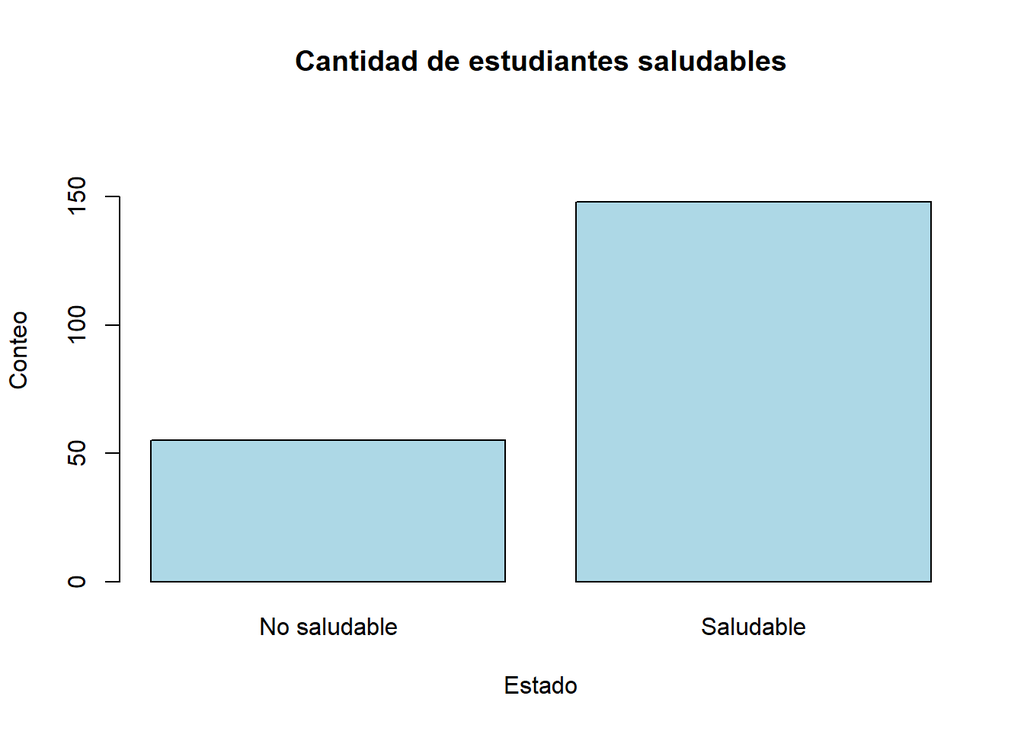

Esto nos permite calcular la probabilidad de un experimento de bernoulli de que un estudiante sea saludable

```r
p <- round(length(which(saludables==TRUE))/length(saludables),2)
p
```

```
## [1] 0.73
```

Por lo cual podemos decir que, segun la data recolectada, el 73% de los estudiantes de esta muestra cumple con las relaciones Peso/Altura correctas para ser considerado saludable.

Continuando, es util saber cual es la probabilidad de que un numero de estudiantes de una muestra sean saludables, ya que se podría saber la esperanza de cuantos estudiantes por aula, o por curso, cumplirían con esta métrica.

#### DEFINICION DE LA VARIABLE

Para ello, definimos una variable aleatoria BINOMIAL:

- **Numero de estudiantes saludables por aula**

Con parámetros

- p: 0.73
- n: 40

Considerando que un aula de clases cuenta con 40 alumnos.

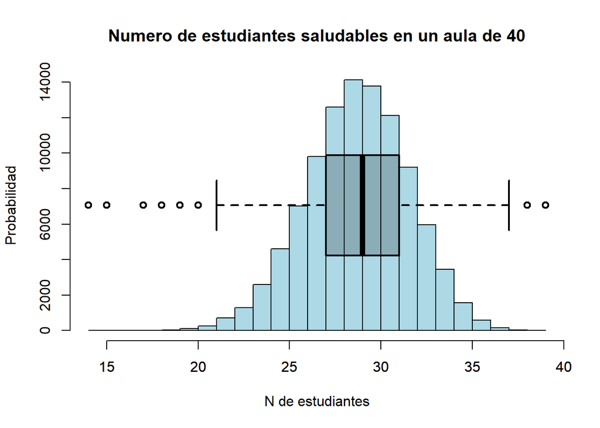

#### CASOS DE USO

Esta variable se puede usar para diferentes tamaños de muestra en la universidad, dependiendo del tamaño del aula o curso a analizar.

1. Probabilidad de que en mi aula de 40 alumnos haya 28 personas saludables

```
## [1] 0.12
```

2. Probabilidad de que en el aula de 40 alumnos haya hasta 30 personas saludables

```
## [1] 0.67
```

[output not shown]

### VARIABLE: PROBABILIDAD DE QUE LA ESTATURA SEA X

#### DEFINICION DEL PROBLEMA

La altura de un estudiante puede significar muchas cosas en la vida estudiantil. A pesar de que para muchos es irrelevante, a muchos jóvenes, especialmente menores, les puede causar inseguridad su altura y pueden sentirse incómodos por ello.

Por ello, decidimos tomar en cuenta la variable continua de Estatura, la cual se definiría de la siguiente manera:

#### DEFINICION DE LA VARIABLE

- **Estatura de los estudiantes**

Esta variable la encontramos ilustrada en nuestra data recolectada, por lo cual, para determinar a que modelo probabilistico se aproxima más, la graficamos:

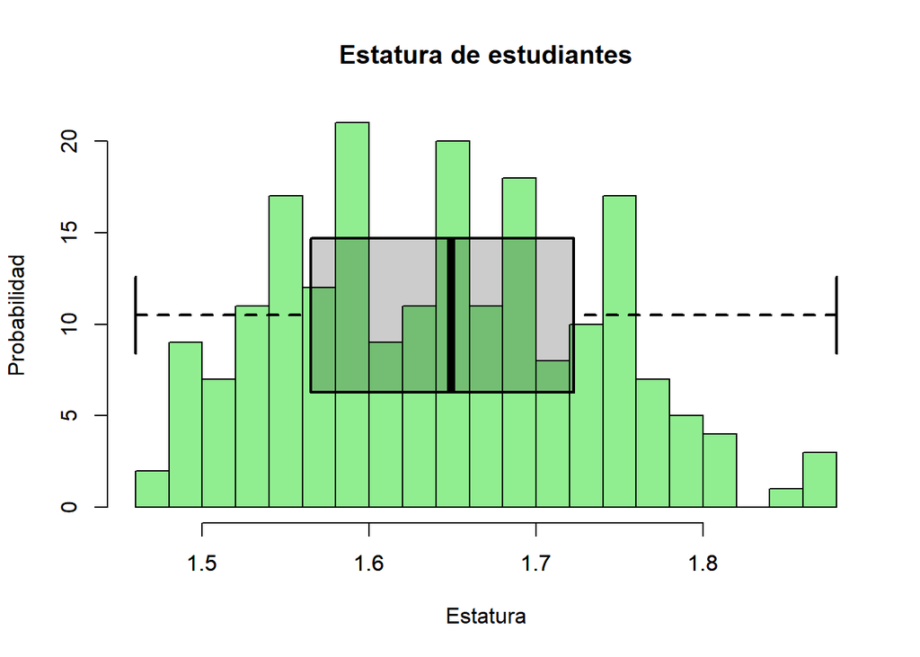

La variable estatura parece tener una distribución normal, aunque no tiene el pico más alto con gran diferencia a los demás, podemos observar que la mayor cantidad de estudiantes entre el rango de 1.55 a 1.74, eso también nos lo indica el boxplot que realizamos.

- **Peso de los estudiantes**

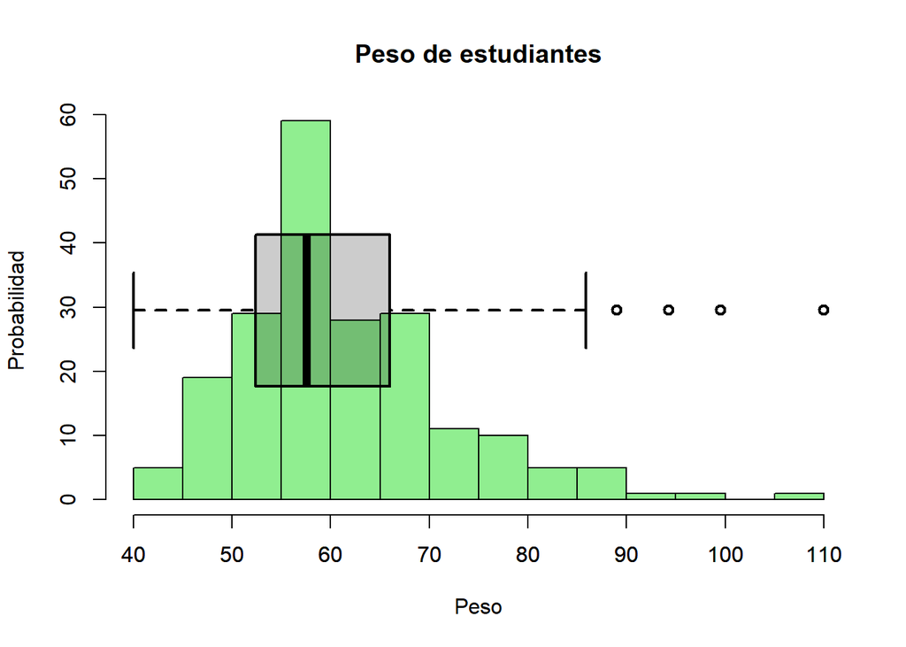

Y con respecto a la variable peso la gráfica tiene la forma de una distribución normal y como podemos observar, esta gráfica si tiene las probabilidades más altas en aproximadamente el peso por 57kg.

## Regresión lineal con relación estatura-peso

Correlación entre estatura y peso

```r
cor(DD$Estatura,DD$Peso)
```

```
## [1] 0.6566439
```

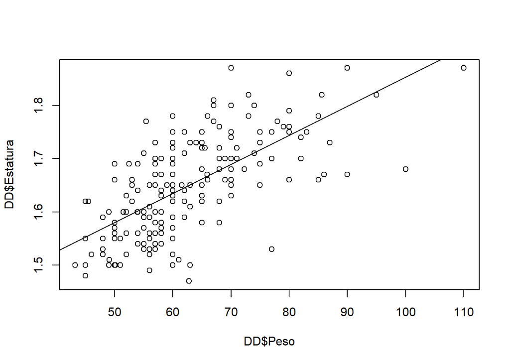

```r
modelo1 <- lm(DD$Estatura~DD$Peso)
plot(DD$Estatura~DD$Peso)
abline(lm(DD$Estatura~DD$Peso))
```

```r
summary(modelo1)
```

```
##
## Call:
## lm(formula = DD$Estatura ~ DD$Peso)
##
## Residuals:
##       Min        1Q    Median        3Q       Max
## -0.197460 -0.046861 -0.002713  0.048531  0.180766
##
## Coefficients:
##              Estimate Std. Error t value Pr(>|t|)
## (Intercept) 1.3069744  0.0279909   46.69   <2e-16 ***
## DD$Peso     0.0054609  0.0004424   12.34   <2e-16 ***
## ---
## Signif. codes:  0 '***' 0.001 '**' 0.01 '*' 0.05 '.' 0.1 ' ' 1
##
## Residual standard error: 0.06887 on 201 degrees of freedom
## Multiple R-squared:  0.4312, Adjusted R-squared:  0.4284
## F-statistic: 152.4 on 1 and 201 DF,  p-value: < 2.2e-16
```

Ya que en el histograma no se puede determinar con claridad si esta variable se aproxima o no a un modelo especifico, usaremos la función **descdist** para visualizar a que modelo se aproxima la data.

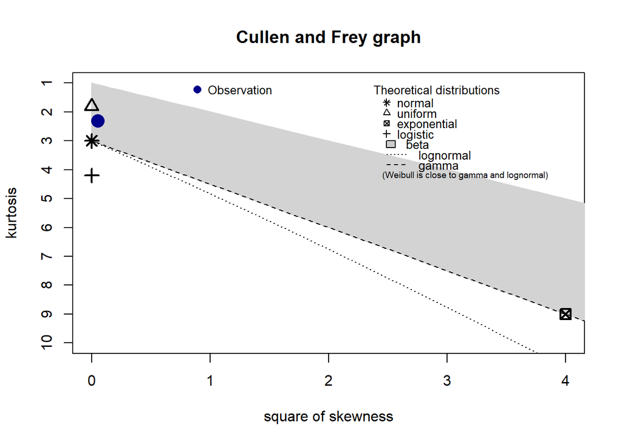

```
## summary statistics
## ------
## min:  1.47   max:  1.87
## median:  1.65
## mean:  1.647291
## estimated sd:  0.09109374
## estimated skewness:  0.225067
## estimated kurtosis:  2.315024
```

Aquí podemos observar que la data recolectada de la estatura de los estudiantes se aproxima a una distribución uniforme continua, pero también es relativamente similar a una normal.

Para efectos de este proyecto, asumiremos que la estatura de los estudiantes se comporta como una variable normal continua, por lo cual calculamos los parámetros

La media y la desviación estándar, que serán las variables mu y sigma respectivamente.

```r
m <- mean(y)
desv <- sd(y)
m
```

```
## [1] 1.647291
```

```r
desv
```

```
## [1] 0.09109374
```

Por lo tanto, asumimos que la variable se comporta como una NORMAL con parámetros:

- mu: 1.647
- sigma: 0.09

#### CASOS DE USO

Esta variable se puede usar para calcular la probabilidad de que un estudiante tenga cierta altura.

1. Probabilidad de que un estudiante mida hasta 1.70 metros

```
## [1] 0.72
```

2. Probabilidad de que un estudiante mida mas de 1.8 metros

```
## [1] 0.05
```

3. Probabilidad de que un estudiante mida hasta 1.55 metros

```
## [1] 0.14
```

### VARIABLE: PROBABILIDAD DE QUE EL ESTUDIANTE N SEA DEPORTISTA

#### DEFINICION DEL PROBLEMA

La vida universitaria puede causar problemas emocionales como estrés y depresión, los cuales a su vez conllevan a malos hábitos alimenticios y problemas de salud. Una de las formas de combatir estos malestares es realizando actividades deportivas.

Queremos conocer cuantos alumnos tengo que conocer para llegar a encontrar uno que sea deportista. Esto podría permitir asegurar conocer a un compañero que puede apoyarme a conseguir mejores hábitos y mejorar mi vida.

Para esto, usaremos la variable **Horas de Ejercicio** recolectada en la encuesta.

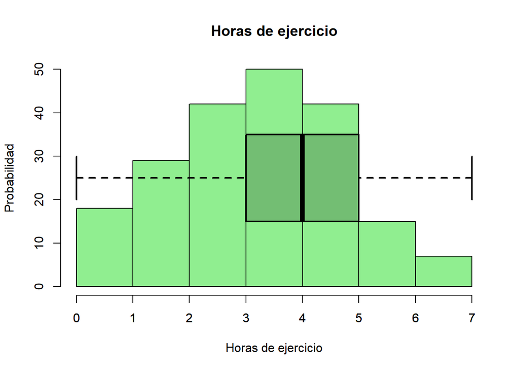

Esta variable es discreta y nos indica cuantas horas a la semana ha realizado ejercicio cada estudiante. Esto nos permitirá definir un experimento bernoulli de éxito-fracaso, en donde:

- Éxito: Hace mas de 4 horas de ejercicio a la semana
- Fracaso: Hace 4 o menos horas de ejercicio a la semana

Para continuar, calcularemos la probabilidad de que se de éxito en nuestra muestra:

```r
p <- round(length(which(z>4))/length(z),2)
p
```

```
## [1] 0.32
```

Por lo tanto pasamos a definir la variable aleatoria.

#### DEFINICION DE LA VARIABLE

- **Numero de estudiantes que debo conocer hasta encontrar uno que sea deportista**

Esta se comporta por definicion como una variable discreta GEOMETRICA, con parametros:

- p: 0.32

La graficamos para visualizar su naturaleza:

[figure not shown]

De esta variable podemos extraer un dato relevante, la esperanza, la cual seria 1/p

```r
1/p
```

```
## [1] 3.125
```

Lo que significa que, en promedio, tengo que conocer a 3.125 alumnos para encontrar a uno deportista. Pero como no puedo conocer a la décima parte de un alumno, esto se puede aproximar a 4.

#### CASOS DE USO

[output not shown]

2. Probabilidad de que encuentre al primer deportista al solo conocer 3 o menos

```
## [1] 0.79
```

3. Probabilidad de que recién al conocer mas de 5 alumnos encuentre uno deportista

```
## [1] 0.1
```